# What's new in Compose Multiplatform 1.9.3

Here are the highlights for this feature release:

- Parameters for the `@Preview` annotation
- Customizable shadows
- New context menu API
- Material 3 Expressive theme
- Frame rate configuration on iOS
- Compose Multiplatform for web in Beta
- Accessibility support on web targets
- skiko.js no longer needed for Kotlin/JS
- New API for embedding HTML content

See the full list of changes for this release on [GitHub](https://github.com/JetBrains/compose-multiplatform/releases/tag/v1.9.0).

## Dependencies

- Gradle Plugin `org.jetbrains.compose`, version 1.9.3. Based on Jetpack Compose libraries:
  - [Runtime 1.9.4](https://developer.android.com/jetpack/androidx/releases/compose-runtime#1.9.4)
  - [UI 1.9.4](https://developer.android.com/jetpack/androidx/releases/compose-ui#1.9.4)
  - [Foundation 1.9.4](https://developer.android.com/jetpack/androidx/releases/compose-foundation#1.9.4)
  - [Material 1.9.4](https://developer.android.com/jetpack/androidx/releases/compose-material#1.9.4)
  - [Material3 1.4.0](https://developer.android.com/jetpack/androidx/releases/compose-material3#1.4.0)
- Compose Material3 libraries `org.jetbrains.compose.material3:1.9.0`. Based on [Jetpack Material3 1.4.0](https://developer.android.com/jetpack/androidx/releases/compose-material3#1.4.0). Thanks to the decoupled versions of Compose Multiplatform and Material3, you can choose a newer pre-release version for your project.
- Compose Material3 Adaptive libraries `org.jetbrains.compose.material3.adaptive:adaptive*:1.2.0`. Based on [Jetpack Material3 Adaptive 1.2.0](https://developer.android.com/jetpack/androidx/releases/compose-material3-adaptive#1.2.0)
- Lifecycle libraries `org.jetbrains.androidx.lifecycle:lifecycle-*:2.9.6`. Based on [Jetpack Lifecycle 2.9.4](https://developer.android.com/jetpack/androidx/releases/lifecycle#2.9.4)
- Navigation libraries `org.jetbrains.androidx.navigation:navigation-*:2.9.1`. Based on [Jetpack Navigation 2.9.4](https://developer.android.com/jetpack/androidx/releases/navigation#2.9.4)
- Savedstate library `org.jetbrains.androidx.savedstate:savedstate:1.3.6`. Based on [Jetpack Savedstate 1.3.3](https://developer.android.com/jetpack/androidx/releases/savedstate#1.3.3)
- WindowManager Core library `org.jetbrains.androidx.window:window-core:1.4.0`. Based on [Jetpack WindowManager 1.4.0](https://developer.android.com/jetpack/androidx/releases/window#1.4.0)

## Across platforms

### Parameters for the `@Preview` annotation

The `@Preview` annotation in Compose Multiplatform now includes additional parameters for configuring how a `@Composable` function is rendered in design-time previews:

- `name`: The display name of the preview.
- `group`: The group name for the preview, enabling the logical organization and selective display of related previews.
- `widthDp`: The maximum width (in dp).
- `heightDp`: The maximum height (in dp).
- `locale`: The current locale of the application.
- `showBackground`: A flag to apply the default background color to the preview.
- `backgroundColor`: A 32-bit ARGB color integer defining the preview’s background color.

These new preview parameters are recognized and work in both IntelliJ IDEA and Android Studio.

### Customizable shadows

In Compose Multiplatform 1.9.0, we’ve introduced customizable shadows, adopting Jetpack Compose’s new shadow primitives and APIs. In addition to the previously supported `shadow` modifier, you can now use the new API to create more advanced and flexible shadow effects.

Two new primitives are available for creating different types of shadows: `DropShadowPainter()` and `InnerShadowPainter()`.

To apply these new shadows to UI components, configure shadow effects with the `dropShadow` or `innerShadow` modifiers:

- ```
          Box(
              Modifier.size(120.dp)
                  .dropShadow(
                      RectangleShape,
                      DropShadow(12.dp)
                  )
                  .background(Color.White)
          )
          Box(
              Modifier.size(120.dp)
                  .innerShadow(
                      RectangleShape,
                      InnerShadow(12.dp)
                  )
          )
  ```

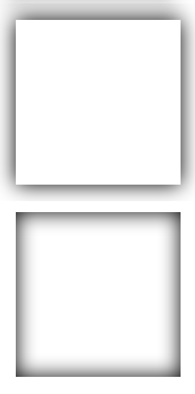

You can draw shadows of any shape and color, or even use shadow geometry as a mask to create an inner gradient-filled shadow:

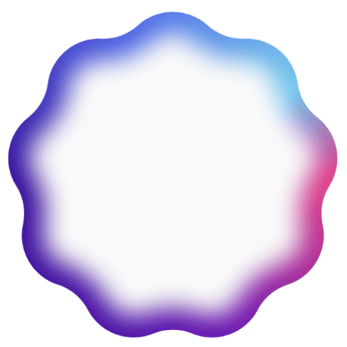

For details, see the [shadow API reference](https://developer.android.com/reference/kotlin/androidx/compose/ui/graphics/shadow/package-summary.html).

### New context menu API

We've adopted Jetpack Compose's new API for custom context menus in `SelectionContainer` and `BasicTextField`. The implementation is complete for iOS and web, while desktop has initial support.

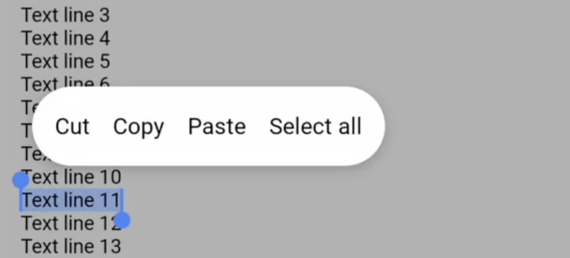

[figure not shown]

To enable this new API, use the following setting at the application entry point:

```
ComposeFoundationFlags.isNewContextMenuEnabled = true
```

For details, see the [context menu API reference](https://developer.android.com/reference/kotlin/androidx/compose/foundation/text/contextmenu/data/package-summary).

### Material 3 Expressive theme

Compose Multiplatform now supports an experimental `MaterialExpressiveTheme` from the Material 3 library. The expressive theming allows you to customize your Material Design app for a more personalized experience.

To use the Expressive theme:

1. Include the experimental version of Material 3:

   ```
   implementation("org.jetbrains.compose.material3:material3:1.9.0-alpha04")
   ```

2. Configure the overall theme of your UI elements using the `MaterialExpressiveTheme()` function. This function requires the `@OptIn(ExperimentalMaterial3ExpressiveApi::class)` opt-in and allows you to specify `colorScheme`, `motionScheme`, `shapes`, and `typography`.

Material components, such as [`Button()`](https://kotlinlang.org/api/compose-multiplatform/material3/androidx.compose.material3/-button.html) and [`Checkbox()`](https://kotlinlang.org/api/compose-multiplatform/material3/androidx.compose.material3/-checkbox.html), will then automatically use the values you’ve provided.

[figure not shown]

### Multiplatform targets in `androidx.compose.runtime:runtime`

To improve Compose Multiplatform's alignment with Jetpack Compose, we've added support for all targets directly into the `androidx.compose.runtime:runtime` artifact.

The `org.jetbrains.compose.runtime:runtime` artifact remains fully compatible and now serves as an alias.

### `runComposeUiTest()` with `suspend` lambda

The `runComposeUiTest()` function now accepts a `suspend` lambda, allowing you to use suspending functions such as `awaitIdle()`.

The new API guarantees correct test execution on all supported platforms, including proper asynchronous handling for web environments:

- For JVM and native targets, `runComposeUiTest()` functions similarly to `runBlocking()`, but skips delays.
- For web targets (Wasm and JS), it returns a `Promise` and executes the test body with delays skipped.

## iOS

### Frame rate configuration

Compose Multiplatform for iOS now supports configuring the preferred frame rate for rendering a composable. If an animation is stuttering, you may want to increase the frame rate. On the other hand, if the animation is slow or static, you may prefer running it at a lower frame rate to reduce power consumption.

You can set the preferred frame rate category as follows:

```
Modifier.preferredFrameRate(FrameRateCategory.High)
```

Alternatively, if you need a specific frame rate for a composable, you can define the preferred frame rate in frames per second using a non-negative number:

```
Modifier.preferredFrameRate(30f)
```

If you apply `preferredFrameRate` multiple times within the same `@Composable` tree, the highest specified value will be applied. However, the device's hardware may limit the supported frame rates, typically up to 120 Hz.

### IME options

Compose Multiplatform 1.9.0 introduces support for iOS-specific IME customization for text input components. You can now use `PlatformImeOptions` to configure native UIKit text input traits such as keyboard type, autocorrection, and return key behavior directly in the text field component:

```
BasicTextField(
    value = "",
    onValueChange = {},
    keyboardOptions = KeyboardOptions(
        platformImeOptions = PlatformImeOptions {
            keyboardType(UIKeyboardTypeEmailAddress)
        }
    )
)
```

## Web

### Compose Multiplatform for web in Beta

Compose Multiplatform for web is now in Beta, making it a great time to give it a try. Check out [our blog post](https://blog.jetbrains.com/kotlin/2025/09/compose-multiplatform-1-9-0-compose-for-web-beta/) to learn more about the progress made to reach this milestone.

As we work toward a stable release, our roadmap includes:

- Implementing support for drag-and-drop functionality in mobile browsers.
- Improving accessibility support.
- Addressing issues related to the `TextField` component.

### Accessibility support

Compose Multiplatform now provides initial accessibility support for the web target. This version enables screen readers to access description labels and allows users to navigate and click buttons in accessible navigation mode.

In this version, the following features are not yet supported:

- Accessibility for interop and container views with scrolls and sliders.
- Traversal indexes.

You can define a component's semantic properties to provide accessibility services with various details, such as the component’s textual description, functional type, current state, or unique identifier.

For example, by setting `Modifier.semantics { heading() }` on a composable, you inform accessibility services that this element acts as a heading, similar to a chapter or a subsection title in a document. Screen readers can then use this information for content navigation, allowing users to jump directly between headings.

```
Text(
    text = "This is heading",
    modifier = Modifier.semantics { heading() }
)
```

Accessibility support is now enabled by default, but you can disable it at any time by adjusting `isA11YEnabled`:

```
ComposeViewport(
    viewportContainer = document.body!!,
    configure = { isA11YEnabled = false }
) {
    Text("Hello, Compose Multiplatform for web")
}
```

### skiko.js is no longer needed

Since Compose Multiplatform 1.7.0, `skiko.js` has been redundant for Kotlin/Wasm applications. As of this release, the same is true for Kotlin/JS: Skiko's web runtime now ships as an ES module and is bundled directly into your app's compiled JavaScript, so a separate `skiko.js` script is no longer required for either web target.

You can remove the `<script src="skiko.js">` tag from your `index.html` file.

### New API for embedding HTML content

With the new `WebElementView()` composable function, you can seamlessly integrate HTML elements into your web application.

The embedded HTML element overlays the canvas area based on the size defined in your Compose code. It intercepts input events within that area, preventing those events from being received by Compose Multiplatform.

Here’s an example of `WebElementView()` being used to create and embed an HTML element that displays an interactive map view within your Compose application:

```
private val ttOSM =
    "https://www.openstreetmap.org/export/embed.html?bbox=4.890965223312379%2C52.33722052818563%2C4.893990755081177%2C52.33860862450587&amp;layer=mapnik"

@Composable
fun Map() {
    Box(
        modifier = Modifier.fillMaxWidth().fillMaxHeight()
    ) {
        WebElementView(
            factory = {
                (document.createElement("iframe")
                        as HTMLIFrameElement)
                    .apply { src = ttOSM }
            },
            modifier = Modifier.fillMaxSize(),
            update = { iframe -> iframe.src = iframe.src }
        )
    }
}
```

Note that you can only use this function with the `ComposeViewport` entry point, as `CanvasBasedWindow` is deprecated.

### Simplified API for binding to the navigation graph

Compose Multiplatform has introduced a new API for binding the browser’s navigation state to the `NavController`:

```
suspend fun NavController.bindToBrowserNavigation()
```

The new function removes the need to interact directly with the `window` API, simplifying both the Kotlin/Wasm and Kotlin/JS source sets.

The previously used `Window.bindToNavigation()` function has been deprecated in favor of the new `NavController.bindToBrowserNavigation()` function.

Before:

```
LaunchedEffect(Unit) {
    // Directly interacts with the window object
    window.bindToNavigation(navController)
}
```

After:

```
LaunchedEffect(Unit) {
    // Implicitly accesses the window object
    navController.bindToBrowserNavigation()
}
```

## Desktop

### Configuring windows before display

Compose Multiplatform now includes new `SwingFrame()` and `SwingDialog()` composables. They are similar to the existing `Window()` and `DialogWindow()` functions but include an `init` block.

Previously, you couldn't set certain window properties that had to be configured before display. The new `init` block executes before your window or dialog appears on the screen, allowing you to configure properties like `java.awt.Window.setType` or add event listeners that need to be ready early.

We recommend using the `init` block only for properties that cannot be changed once the window or dialog is visible. For all other configurations, continue using the `LaunchedEffect(window)` pattern to ensure your code remains compatible and works correctly with future updates.

## Gradle plugin

### Decoupled Material3 versioning

The versions and stability levels of the Material3 library and Compose Multiplatform Gradle plugin no longer have to be aligned. The `compose.material3` DSL alias references Material3 1.9.0 from the stable release of Jetpack Compose, but you can choose a pre-release version for your project.

If you want to use a Material3 version with Expressive design support, replace the Material 3 dependency in `build.gradle.kts` with the following:

```
implementation("org.jetbrains.compose.material3:material3:1.9.0-alpha04")
```

### Unified web distribution

The new `composeCompatibilityBrowserDistribution` Gradle task combines Kotlin/JS and Kotlin/Wasm distributions into a single package. This allows Wasm applications to fall back to the JS target when modern Wasm features are not supported by a browser.

### Support for AGP 9.0.0

Compose Multiplatform introduces support for version 9.0.0 of the Android Gradle Plugin (AGP). For compatibility with the new AGP version, make sure you upgrade to Compose Multiplatform 1.9.3 or 1.10.0.

To make the update process smoother in the long term, we recommend changing your project structure to use a dedicated Android application module.

31 July 2026